# Region Synthetic Controls

We want to create synthetic controls at the region-level.

The outcome variable is

- number of purchases made in a region each week.

The matching covariates are:

- number of users
- number of restaurants
- average number of purchases made by users per week?
- average amount spent by users
- average number of sales made by restaurant per day
- average amount spent at restaurants
- average rating of restaurants

In the code below I count the total number of transactions per region per week. This is the outcome variable.

```r
df_purchases <- df_cust_trans_exist %>%
  filter(week >= 7 & week != 11 & week <= 15) %>%
  group_by(rest_area_id, week, treated) %>%
  summarise(purchases = n())
```

In the code below I use data from the customer - weekly level to calculate trials per region per week.

```r
df_cust_area <- df_cust_trans_exist %>%
  group_by(cust_id) %>%
  summarise(cust_area_id = mfv(rest_area_id))
```

```r
df_trials <- df_cust_longer_NA %>%
  select(cust_id, week, distinct) %>%
  filter(week >= 7 & week != 11 & week <= 15) %>%
  left_join(df_cust_area, by = c("cust_id")) %>%
  group_by(cust_area_id, week) %>%
  summarise(trials = sum(distinct, na.rm = TRUE)) %>%
  rename(rest_area_id = cust_area_id)
```

In the code below I count the distinct number of customers per region, and distinct number of restaurants per region. The problem with the number of customers is that it will double count customers who have purchased from restaurants in different regions.

```r
df_num <- df_cust_trans_exist %>%
  filter(week >= 7 & week < 11) %>%
  group_by(rest_area_id) %>%
  summarise(num_cust = n_distinct(cust_id),
            num_rest = n_distinct(rest_id))
```

In the code below I find the average frequency of purchase by users per region in the pre experiment period.

```r
df_cust <- df_cust_longer_NA %>%
  filter(week >= 7 & week < 11) %>%
  left_join(df_cust_area, by = c("cust_id")) %>%
  group_by(cust_area_id) %>%
  summarise(avg_cust_spend = mean(avg_spend),
            avg_freq_week = mean(count)) %>%
  rename(rest_area_id = cust_area_id)
```

In the code below I create restaurant characteristics at the region level.

```r
df_rest <- df_cust_trans_exist %>%
  group_by(rest_area_id) %>%
  summarise(avg_sales = mean(rest_daily_sales),
            avg_bill = mean(rest_pre_bill),
            avg_rating = mean(rest_pre_rating))
```

In the code below I join the data frames and add some filters to make the data compatible with the synth package.

```r
df_synth <- df_purchases %>%
  filter(rest_area_id != 302 & rest_area_id != 303) %>%
  left_join(df_trials, by = c("rest_area_id", "week")) %>%
  left_join(df_num, by = c("rest_area_id")) %>%
  left_join(df_cust, by = c("rest_area_id")) %>%
  left_join(df_rest, by = c("rest_area_id")) %>%
  as.data.frame()
```

### Both outcomes, all covariates

```r
cov.var <- c("num_cust", "num_rest", "avg_freq_week", "avg_cust_spend", "avg_sales", "avg_bill", "avg_rating")
match.out <- c("purchases", "trials")

synth <- microsynth(df_synth,
                    idvar = "rest_area_id", timevar = "week", intvar = "treated",
                    start.pre = 7, end.pre = 10, end.post = 15,
                    match.out = match.out, match.covar = cov.var,
                    result.var = match.out, omnibus.var = match.out,
                    use.backup = TRUE,
                    n.cores = min(parallel::detectCores(), 2))
```

```
## WARNING: There is a low number (1) of cases in the treatment or intervention group.
```

```
## Setting use.survey = FALSE.
```

```
## Be cautious of results involving linearization or confidence intervals.
```

```
## Calculating weights...
```

```
## First and second model are infeasible for primary weights.  Will use third model.
```

```
## Created main weights for synthetic control: Time = 1.74
```

```
## Matching summary for main weights:
```

```
##                  Targets Final.Weighted.Control All.scaled
## Intercept         1.0000                 1.0000     1.0000
## num_cust       1583.0000              1751.4774  6731.5556
## num_rest         56.0000                18.8159    81.4074
## avg_freq_week     0.3499                 0.3506     0.5151
## avg_cust_spend   63.2545                64.2128    93.8512
## avg_sales        14.9636                12.7232    21.0056
## avg_bill        298.0619               269.3193   315.1433
## avg_rating        3.5415                 3.5376     3.5586
## purchases.10   1312.0000              1219.9242  4672.1481
## purchases.9    1257.0000              1206.4857  4658.7037
## purchases.8    1393.0000              1264.0896  4797.2222
## purchases.7    1291.0000              1207.6874  4689.4074
## trials.10       526.0000               535.3295  2400.4815
## trials.9        475.0000               563.6730  2474.8148
## trials.8        548.0000               589.4584  2581.1111
## trials.7        561.0000               584.3457  2615.0000
##
## Calculation of weights complete: Total time = 1.76
##
## Calculating basic statistics for end.post = 15...
## Completed calculation of basic statistics for end.post = 15.  Time = 0
##
## Calculating survey statistics for end.post = 15...
## Completed survey statistics for main weights: Time = 0.08
## Completed calculation of survey statistics for end.post = 15.  Time = 0.09
##
## microsynth complete: Overall time = 1.89
```

```r
summary(synth)
```

```
## Weight Balance Table:
##
##                     Targets Final.Weighted.Control   All.scaled
## Intercept         1.0000000              1.0000000    1.0000000
## num_cust       1583.0000000           1751.4773773 6731.5555556
## num_rest         56.0000000             18.8158527   81.4074074
## avg_freq_week     0.3499201              0.3505743    0.5151165
## avg_cust_spend   63.2544985             64.2128059   93.8512370
## avg_sales        14.9636281             12.7232409   21.0055716
## avg_bill        298.0618681            269.3192834  315.1433481
## avg_rating        3.5414548              3.5376120    3.5586127
## purchases.10   1312.0000000           1219.9242419 4672.1481481
## purchases.9    1257.0000000           1206.4857416 4658.7037037
## purchases.8    1393.0000000           1264.0896292 4797.2222222
## purchases.7    1291.0000000           1207.6874451 4689.4074074
## trials.10       526.0000000            535.3294792 2400.4814815
## trials.9        475.0000000            563.6729937 2474.8148148
## trials.8        548.0000000            589.4583732 2581.1111111
## trials.7        561.0000000            584.3457459 2615.0000000
##
## Results:
##
## end.post = 15
##            Trt     Con Pct.Chng Linear.pVal Linear.Lower Linear.Upper
## purchases 4946 4401.69    12.4%      0.7695       -43.9%       125.0%
## trials    1611 1737.99    -7.3%      0.8924       -61.9%       125.4%
## Omnibus     --      --       --      0.0000           --           --
```

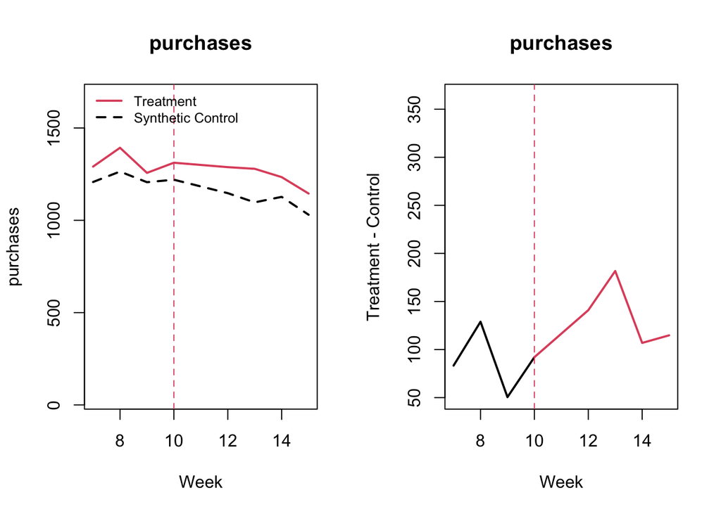

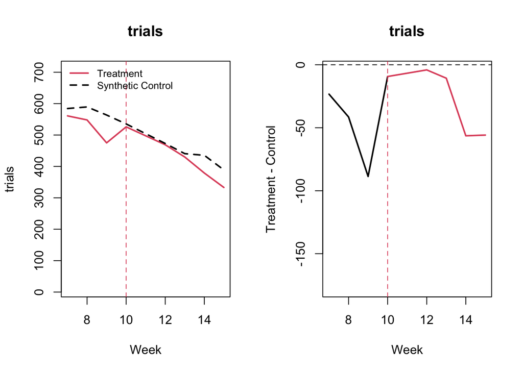

```r
plot_microsynth(synth, end.pre = 10, legend.spot = "topleft",
                # main.tc = c("Purchases", "Trials"), main.diff = "Difference",
                xlab.tc = "Week", xlab.diff = "Week",
                all = NULL
                # ylab.tc = "Purchases"
                )
```

### Purchases, all covariates

```r
cov.var <- c("num_cust", "num_rest", "avg_freq_week", "avg_cust_spend", "avg_sales", "avg_bill", "avg_rating")
match.out <- c("purchases")

synth <- microsynth(df_synth,
                    idvar = "rest_area_id", timevar = "week", intvar = "treated",
                    start.pre = 7, end.pre = 10, end.post = 15,
                    match.out = match.out, match.covar = cov.var,
                    result.var = match.out, omnibus.var = match.out,
                    use.backup = TRUE,
                    n.cores = min(parallel::detectCores(), 2))
```

```
## WARNING: There is a low number (1) of cases in the treatment or intervention group.
```

```
## Setting use.survey = FALSE.
```

```
## Be cautious of results involving linearization or confidence intervals.
```

```
## Calculating weights...
```

```
## First and second model are infeasible for primary weights.  Will use third model.
```

```
## Created main weights for synthetic control: Time = 0.32
```

```
## Matching summary for main weights:
```

```
##                  Targets Final.Weighted.Control All.scaled
## Intercept         1.0000                 1.0000     1.0000
## num_cust       1583.0000              1724.3987  6731.5556
## num_rest         56.0000                24.8814    81.4074
## avg_freq_week     0.3499                 0.3754     0.5151
## avg_cust_spend   63.2545                79.5104    93.8512
## avg_sales        14.9636                11.8737    21.0056
## avg_bill        298.0619               320.7519   315.1433
## avg_rating        3.5415                 3.4587     3.5586
## purchases.10   1312.0000              1265.4900  4672.1481
## purchases.9    1257.0000              1277.0279  4658.7037
## purchases.8    1393.0000              1310.6380  4797.2222
## purchases.7    1291.0000              1294.3975  4689.4074
##
## Calculation of weights complete: Total time = 0.33
##
## Calculating basic statistics for end.post = 15...
## Completed calculation of basic statistics for end.post = 15.  Time = 0
##
## Calculating survey statistics for end.post = 15...
## Completed survey statistics for main weights: Time = 0.01
## Completed calculation of survey statistics for end.post = 15.  Time = 0.01
##
## microsynth complete: Overall time = 0.36
```

```r
summary(synth)
```

```
## Weight Balance Table:
##
##                     Targets Final.Weighted.Control   All.scaled
## Intercept         1.0000000              1.0000000    1.0000000
## num_cust       1583.0000000           1724.3986993 6731.5555556
## num_rest         56.0000000             24.8813973   81.4074074
## avg_freq_week     0.3499201              0.3754218    0.5151165
## avg_cust_spend   63.2544985             79.5103546   93.8512370
## avg_sales        14.9636281             11.8736642   21.0055716
## avg_bill        298.0618681            320.7518872  315.1433481
## avg_rating        3.5414548              3.4586708    3.5586127
## purchases.10   1312.0000000           1265.4900258 4672.1481481
## purchases.9    1257.0000000           1277.0278737 4658.7037037
## purchases.8    1393.0000000           1310.6380478 4797.2222222
## purchases.7    1291.0000000           1294.3974724 4689.4074074
##
## Results:
##
## end.post = 15
##            Trt     Con Pct.Chng Linear.pVal Linear.Lower Linear.Upper
## purchases 4946 4522.71     9.4%      0.8376       -48.4%       131.8%
```

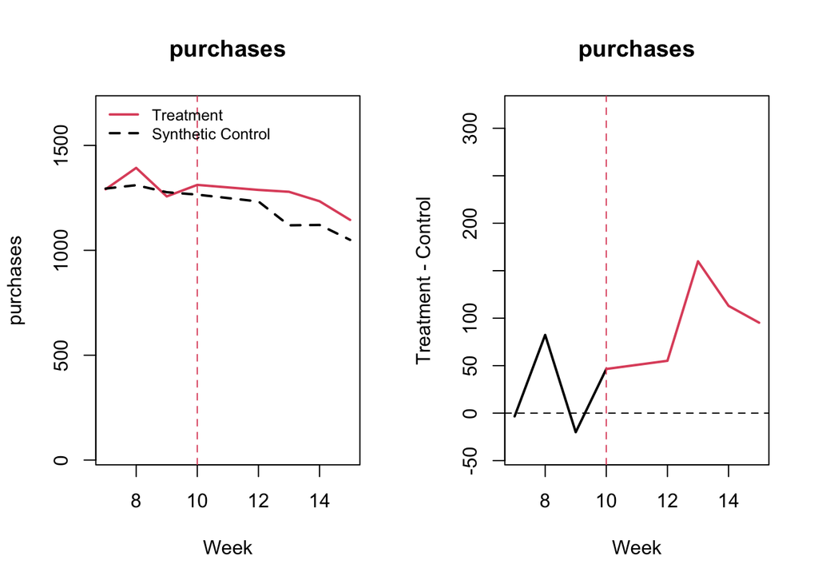

```r
plot_microsynth(synth, end.pre = 10, legend.spot = "topleft",
                # main.tc = c("Purchases", "Trials"), main.diff = "Difference",
                xlab.tc = "Week", xlab.diff = "Week",
                all = NULL
                # ylab.tc = "Purchases"
                )
```

### Trials, all covariates

```r
cov.var <- c("num_cust", "num_rest", "avg_freq_week", "avg_cust_spend", "avg_sales", "avg_bill", "avg_rating")
match.out <- c("trials")

synth <- microsynth(df_synth,
                    idvar = "rest_area_id", timevar = "week", intvar = "treated",
                    start.pre = 7, end.pre = 10, end.post = 15,
                    match.out = match.out, match.covar = cov.var,
                    result.var = match.out, omnibus.var = match.out,
                    use.backup = TRUE,
                    n.cores = min(parallel::detectCores(), 2))
```

```
## WARNING: There is a low number (1) of cases in the treatment or intervention group.
```

```
## Setting use.survey = FALSE.
```

```
## Be cautious of results involving linearization or confidence intervals.
```

```
## Calculating weights...
```

```
## First and second model are infeasible for primary weights.  Will use third model.
```

```
## Created main weights for synthetic control: Time = 0.34
```

```
## Matching summary for main weights:
```

```
##                  Targets Final.Weighted.Control All.scaled
## Intercept         1.0000                 1.0000     1.0000
## num_cust       1583.0000              1610.8568  6731.5556
## num_rest         56.0000                23.9715    81.4074
## avg_freq_week     0.3499                 0.3737     0.5151
## avg_cust_spend   63.2545                77.7455    93.8512
## avg_sales        14.9636                12.2416    21.0056
## avg_bill        298.0619               313.8509   315.1433
## avg_rating        3.5415                 3.4687     3.5586
## trials.10       526.0000               509.3933  2400.4815
## trials.9        475.0000               501.0846  2474.8148
## trials.8        548.0000               536.4959  2581.1111
## trials.7        561.0000               552.0554  2615.0000
##
## Calculation of weights complete: Total time = 0.35
##
## Calculating basic statistics for end.post = 15...
## Completed calculation of basic statistics for end.post = 15.  Time = 0
##
## Calculating survey statistics for end.post = 15...
## Completed survey statistics for main weights: Time = 0.01
## Completed calculation of survey statistics for end.post = 15.  Time = 0.01
##
## microsynth complete: Overall time = 0.39
```

```r
summary(synth)
```

```
## Weight Balance Table:
##
##                     Targets Final.Weighted.Control   All.scaled
## Intercept         1.0000000              1.0000000    1.0000000
## num_cust       1583.0000000           1610.8567839 6731.5555556
## num_rest         56.0000000             23.9715035   81.4074074
## avg_freq_week     0.3499201              0.3736752    0.5151165
## avg_cust_spend   63.2544985             77.7455499   93.8512370
## avg_sales        14.9636281             12.2416185   21.0055716
## avg_bill        298.0618681            313.8509302  315.1433481
## avg_rating        3.5414548              3.4686856    3.5586127
## trials.10       526.0000000            509.3932616 2400.4814815
## trials.9        475.0000000            501.0845641 2474.8148148
## trials.8        548.0000000            536.4958935 2581.1111111
## trials.7        561.0000000            552.0553999 2615.0000000
##
## Results:
##
## end.post = 15
##         Trt     Con Pct.Chng Linear.pVal Linear.Lower Linear.Upper
## trials 1611 1604.09     0.4%      0.9911       -47.0%        90.2%
```

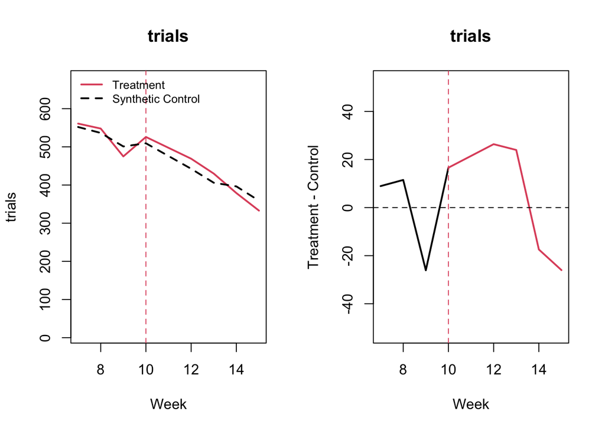

```r
plot_microsynth(synth, end.pre = 10, legend.spot = "topleft",
                # main.tc = c("Purchases", "Trials"), main.diff = "Difference",
                xlab.tc = "Week", xlab.diff = "Week",
                all = NULL
                # ylab.tc = "Purchases"
                )
```

### Both outcomes, only restaurant related covariates

```r
cov.var <- c("num_rest", "avg_sales", "avg_bill", "avg_rating")
match.out <- c("purchases", "trials")

synth <- microsynth(df_synth,
                    idvar = "rest_area_id", timevar = "week", intvar = "treated",
                    start.pre = 7, end.pre = 10, end.post = 15,
                    match.out = match.out, match.covar = cov.var,
                    result.var = match.out, omnibus.var = match.out,
                    use.backup = TRUE,
                    n.cores = min(parallel::detectCores(), 2))
```

```
## WARNING: There is a low number (1) of cases in the treatment or intervention group.
```

```
## Setting use.survey = FALSE.
```

```
## Be cautious of results involving linearization or confidence intervals.
```

```
## Calculating weights...
```

```
## First and second model are infeasible for primary weights.  Will use third model.
```

```
## Created main weights for synthetic control: Time = 0.3
```

```
## Matching summary for main weights:
```

```
##                Targets Final.Weighted.Control All.scaled
## Intercept       1.0000                 1.0000     1.0000
## num_rest       56.0000                31.0553    81.4074
## avg_sales      14.9636                15.4321    21.0056
## avg_bill      298.0619               302.0907   315.1433
## avg_rating      3.5415                 3.4749     3.5586
## purchases.10 1312.0000              1339.1754  4672.1481
## purchases.9  1257.0000              1261.6384  4658.7037
## purchases.8  1393.0000              1354.1551  4797.2222
## purchases.7  1291.0000              1292.2334  4689.4074
## trials.10     526.0000               516.0225  2400.4815
## trials.9      475.0000               507.6004  2474.8148
## trials.8      548.0000               550.8699  2581.1111
## trials.7      561.0000               553.3684  2615.0000
##
## Calculation of weights complete: Total time = 0.3
##
## Calculating basic statistics for end.post = 15...
## Completed calculation of basic statistics for end.post = 15.  Time = 0
##
## Calculating survey statistics for end.post = 15...
## Completed survey statistics for main weights: Time = 0.11
## Completed calculation of survey statistics for end.post = 15.  Time = 0.11
##
## microsynth complete: Overall time = 0.43
```

```r
summary(synth)
```

```
## Weight Balance Table:
##
##                  Targets Final.Weighted.Control  All.scaled
## Intercept       1.000000               1.000000    1.000000
## num_rest       56.000000              31.055336   81.407407
## avg_sales      14.963628              15.432071   21.005572
## avg_bill      298.061868             302.090679  315.143348
## avg_rating      3.541455               3.474906    3.558613
## purchases.10 1312.000000            1339.175375 4672.148148
## purchases.9  1257.000000            1261.638422 4658.703704
## purchases.8  1393.000000            1354.155083 4797.222222
## purchases.7  1291.000000            1292.233435 4689.407407
## trials.10     526.000000             516.022505 2400.481481
## trials.9      475.000000             507.600376 2474.814815
## trials.8      548.000000             550.869853 2581.111111
## trials.7      561.000000             553.368417 2615.000000
##
## Results:
##
## end.post = 15
##            Trt     Con Pct.Chng Linear.pVal Linear.Lower Linear.Upper
## purchases 4946 4817.84     2.7%      0.8309       -16.4%        26.0%
## trials    1611 1688.74    -4.6%      0.7305       -23.4%        18.9%
## Omnibus     --      --       --      0.5420           --           --
```

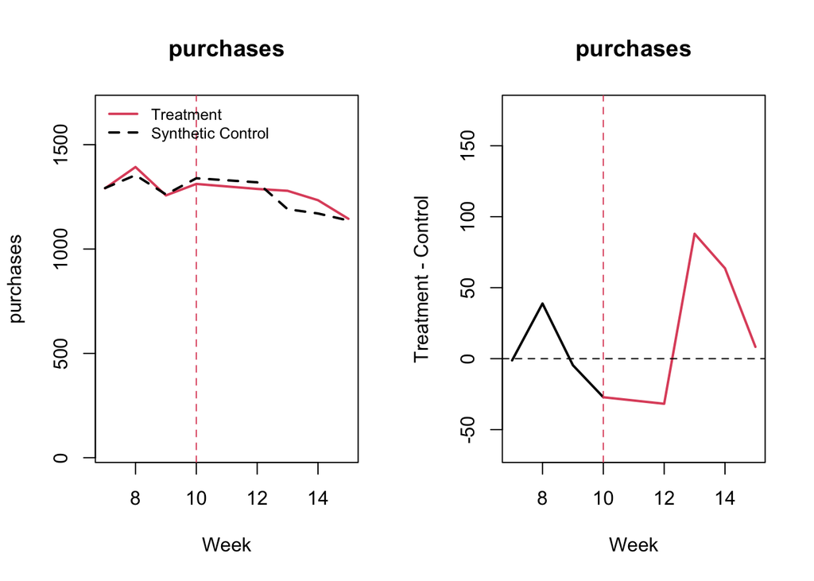

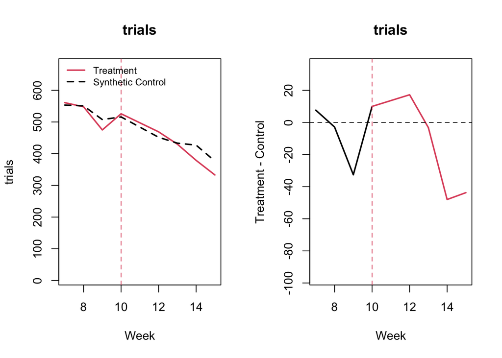

```r
plot_microsynth(synth, end.pre = 10, legend.spot = "topleft",
                # main.tc = c("Purchases", "Trials"), main.diff = "Difference",
                xlab.tc = "Week", xlab.diff = "Week",
                all = NULL
                # ylab.tc = "Purchases"
                )
```

### Both outcomes, only customer related covariates

```r
cov.var <- c("num_cust", "avg_freq_week", "avg_cust_spend")
match.out <- c("purchases", "trials")

synth <- microsynth(df_synth,
                    idvar = "rest_area_id", timevar = "week", intvar = "treated",
                    start.pre = 7, end.pre = 10, end.post = 15,
                    match.out = match.out, match.covar = cov.var,
                    result.var = match.out, omnibus.var = match.out,
                    use.backup = TRUE,
                    n.cores = min(parallel::detectCores(), 2))
```

```
## WARNING: There is a low number (1) of cases in the treatment or intervention group.
```

```
## Setting use.survey = FALSE.
```

```
## Be cautious of results involving linearization or confidence intervals.
```

```
## Calculating weights...
```

```
## First and second model are infeasible for primary weights.  Will use third model.
```

```
## Created main weights for synthetic control: Time = 0.3
```

```
## Matching summary for main weights:
```

```
##                  Targets Final.Weighted.Control All.scaled
## Intercept         1.0000                 1.0000     1.0000
## num_cust       1583.0000              1782.8740  6731.5556
## avg_freq_week     0.3499                 0.3443     0.5151
## avg_cust_spend   63.2545                60.0811    93.8512
## purchases.10   1312.0000              1231.1990  4672.1481
## purchases.9    1257.0000              1211.8491  4658.7037
## purchases.8    1393.0000              1277.0155  4797.2222
## purchases.7    1291.0000              1208.2984  4689.4074
## trials.10       526.0000               526.7664  2400.4815
## trials.9        475.0000               555.1759  2474.8148
## trials.8        548.0000               578.6267  2581.1111
## trials.7        561.0000               566.2709  2615.0000
##
## Calculation of weights complete: Total time = 0.31
##
## Calculating basic statistics for end.post = 15...
## Completed calculation of basic statistics for end.post = 15.  Time = 0
##
## Calculating survey statistics for end.post = 15...
## Completed survey statistics for main weights: Time = 0.07
## Completed calculation of survey statistics for end.post = 15.  Time = 0.07
##
## microsynth complete: Overall time = 0.4
```

```r
summary(synth)
```

```
## Weight Balance Table:
##
##                     Targets Final.Weighted.Control   All.scaled
## Intercept         1.0000000              1.0000000    1.0000000
## num_cust       1583.0000000           1782.8739829 6731.5555556
## avg_freq_week     0.3499201              0.3442953    0.5151165
## avg_cust_spend   63.2544985             60.0811415   93.8512370
## purchases.10   1312.0000000           1231.1989609 4672.1481481
## purchases.9    1257.0000000           1211.8491409 4658.7037037
## purchases.8    1393.0000000           1277.0154853 4797.2222222
## purchases.7    1291.0000000           1208.2983658 4689.4074074
## trials.10       526.0000000            526.7663813 2400.4814815
## trials.9        475.0000000            555.1758989 2474.8148148
## trials.8        548.0000000            578.6267150 2581.1111111
## trials.7        561.0000000            566.2709303 2615.0000000
##
## Results:
##
## end.post = 15
##            Trt     Con Pct.Chng Linear.pVal Linear.Lower Linear.Upper
## purchases 4946 4452.70    11.1%      0.8122       -48.4%       139.2%
## trials    1611 1715.17    -6.1%      0.9203       -65.4%       155.1%
## Omnibus     --      --       --      0.0000           --           --
```

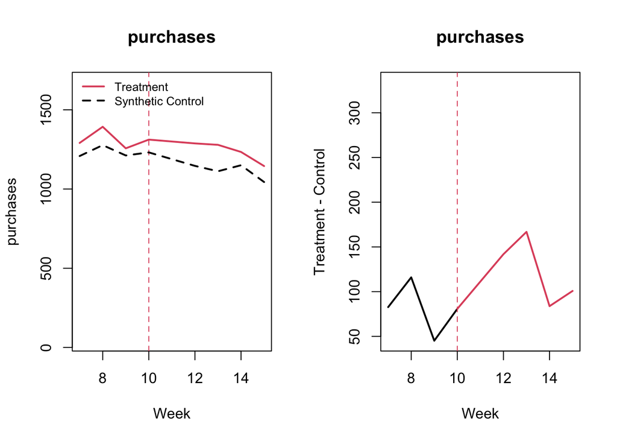

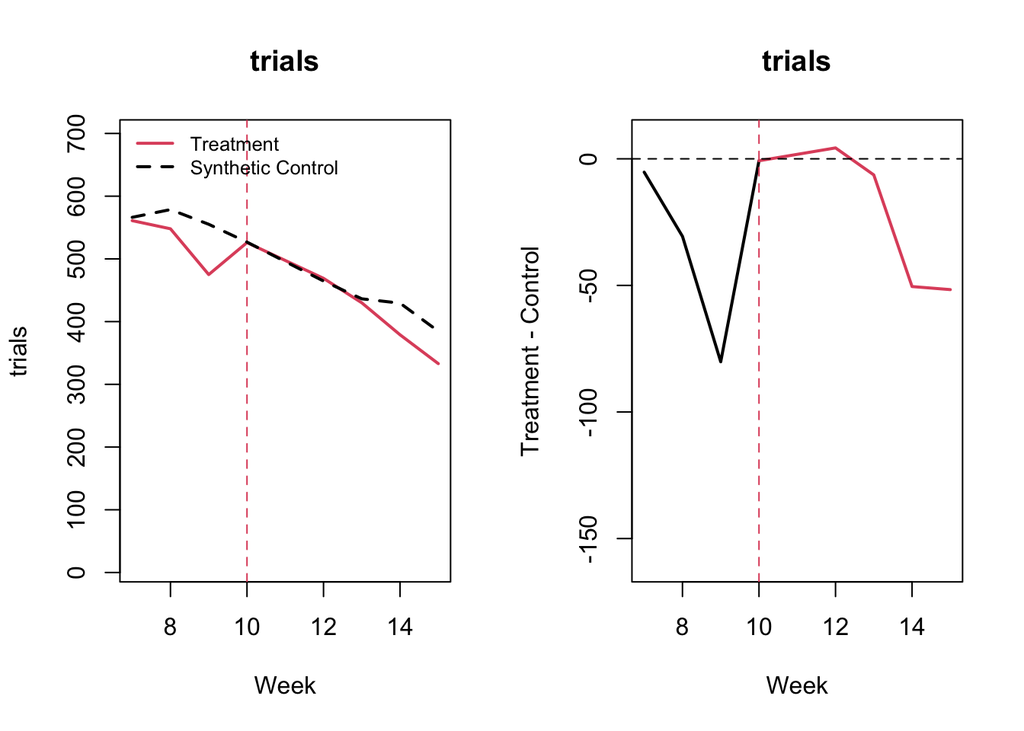

```r
plot_microsynth(synth, end.pre = 10, legend.spot = "topleft",
                # main.tc = c("Purchases", "Trials"), main.diff = "Difference",
                xlab.tc = "Week", xlab.diff = "Week",
                all = NULL
                # ylab.tc = "Purchases"
                )
```